# Final Project Check Up Memo #2

Data Science 2 with R (STAT 301-2)

Author

Kayla Terrelonge

## Load Packages

```r
library(tidyverse)
library(janitor)
library(skimr)
```

## Confirmation of Data

Since the last check in memo, because of issues with missingness and complications with the data, I was granted to use my data set from last quarter’s final project. Because I did significant data cleaning, webscrapping, and tidying, the data set is tidy and clean. The data was collected from 20 years worth of ESPN stats. It contains 27 variables with 21 numeric variables. It will be read in below.

## Data Assurance and Validation Checks

```r
nba <- read_csv("data/processed_data/nba_players.csv")
```

```r
nba <- nba %>%
  # fixing any inconsistency in naming
  janitor::clean_names() %>%
  # changing variables as factor
  mutate(conference = as.factor(conference),
         team = as.factor(team),
         team_class = as.factor(team_class),
         pos = as.factor(pos))
# writing out to data folder
write_csv(nba, "data/processed_data/nba_players.csv")
```

There were some minor issues with reading in, `team`, `conference`, `pos`, and `team_class` should have been treated as a factor, but it was treated as a character variable.

```r
skim_without_charts(nba)
```

Data summary

| Name | nba |
| --- | --- |
| Number of rows | 10905 |
| Number of columns | 27 |
| _______________________ |  |
| Column type frequency: |  |
| character | 2 |
| factor | 4 |
| numeric | 21 |
| ________________________ |  |
| Group variables | None |

**Variable type: character**

| skim_variable | n_missing | complete_rate | min | max | empty | n_unique | whitespace |
| --- | --- | --- | --- | --- | --- | --- | --- |
| name | 0 | 1 | 4 | 24 | 0 | 2159 | 0 |
| season | 1 | 1 | 9 | 9 | 0 | 21 | 0 |

**Variable type: factor**

| skim_variable | n_missing | complete_rate | ordered | n_unique | top_counts |
| --- | --- | --- | --- | --- | --- |
| pos | 10 | 1 | FALSE | 8 | C: 1961, PF: 1830, SG: 1695, PG: 1681 |
| team | 0 | 1 | FALSE | 32 | HOU: 408, MEM: 396, CLE: 390, PHI: 389 |
| team_class | 0 | 1 | FALSE | 2 | tea: 9593, sec: 1312 |
| conference | 0 | 1 | FALSE | 2 | Eas: 5454, Wes: 5451 |

**Variable type: numeric**

| skim_variable | n_missing | complete_rate | mean | sd | p0 | p25 | p50 | p75 | p100 |
| --- | --- | --- | --- | --- | --- | --- | --- | --- | --- |
| rank | 0 | 1 | 239.32 | 138.47 | 1.00 | 120.00 | 238.00 | 355.00 | 581.00 |
| gp | 0 | 1 | 52.11 | 24.38 | 1.00 | 33.00 | 59.00 | 73.00 | 85.00 |
| min | 0 | 1 | 20.22 | 9.66 | 0.70 | 12.30 | 19.60 | 28.00 | 43.70 |
| pts | 0 | 1 | 8.24 | 5.88 | 0.10 | 3.70 | 6.80 | 11.50 | 36.10 |
| fgm | 0 | 1 | 3.07 | 2.14 | 0.00 | 1.40 | 2.60 | 4.30 | 12.20 |
| fga | 0 | 1 | 6.86 | 4.54 | 0.00 | 3.30 | 5.70 | 9.40 | 27.80 |
| fg_percent | 0 | 1 | 44.08 | 8.78 | 0.00 | 40.00 | 43.80 | 48.10 | 100.00 |
| x3_pm | 0 | 1 | 0.65 | 0.72 | 0.00 | 0.00 | 0.40 | 1.10 | 5.30 |
| x3pa | 0 | 1 | 1.86 | 1.90 | 0.00 | 0.10 | 1.40 | 3.00 | 13.20 |
| x3p_percent | 0 | 1 | 25.50 | 16.97 | 0.00 | 10.00 | 31.50 | 36.80 | 100.00 |
| ftm | 0 | 1 | 1.45 | 1.37 | 0.00 | 0.50 | 1.00 | 1.90 | 10.20 |
| fta | 0 | 1 | 1.93 | 1.71 | 0.00 | 0.80 | 1.40 | 2.60 | 11.80 |
| ft_percent | 0 | 1 | 71.11 | 18.37 | 0.00 | 65.40 | 75.00 | 82.00 | 100.00 |
| reb | 0 | 1 | 3.56 | 2.42 | 0.00 | 1.80 | 3.00 | 4.70 | 16.00 |
| ast | 0 | 1 | 1.82 | 1.77 | 0.00 | 0.60 | 1.20 | 2.40 | 11.70 |
| stl | 0 | 1 | 0.63 | 0.42 | 0.00 | 0.30 | 0.60 | 0.90 | 2.90 |
| blk | 0 | 1 | 0.40 | 0.45 | 0.00 | 0.10 | 0.30 | 0.50 | 3.70 |
| to | 0 | 1 | 1.15 | 0.78 | 0.00 | 0.60 | 1.00 | 1.50 | 5.70 |
| dd2 | 0 | 1 | 4.17 | 9.03 | 0.00 | 0.00 | 0.00 | 3.00 | 71.00 |
| td3 | 0 | 1 | 0.12 | 1.06 | 0.00 | 0.00 | 0.00 | 0.00 | 42.00 |
| per | 2 | 1 | 12.41 | 6.23 | -16.69 | 9.36 | 12.52 | 15.76 | 133.95 |

There is no significant issues with missingness. The position (`pos`) variable has the highest amount of missing observations, with 10 being missing. This could easily just be due to inconsistencies in data collection. However, since the data contains information for players each year, if the player played in another year for the same team, the value can be imputed from this.

```r
# creating a correlation matrix
corr_nba <- nba %>%
  select(-c(name, season, pos, team, team_class, conference)) %>%
  cor()

corr_nba[4,]
```

```
       rank          gp         min         pts         fgm         fga
 -0.9168849   0.5313287   0.8898175   1.0000000   0.9894573   0.9819110
 fg_percent       x3_pm        x3pa x3p_percent         ftm         fta
  0.2230723   0.5947795   0.5983646   0.2957437   0.8935437   0.8750190
 ft_percent         reb         ast         stl         blk          to
  0.3598622   0.6151760   0.6661533   0.6814767   0.3162067   0.8391959
        dd2         td3         per
  0.5739370   0.2397840          NA
```

It seems that the outcome variable of `pts` has a strong correlation with `rank`, `min`,`fgm`,`fga`,and `to`. A scatterplot with this variables will be created to asses if there is a need for data transformations.

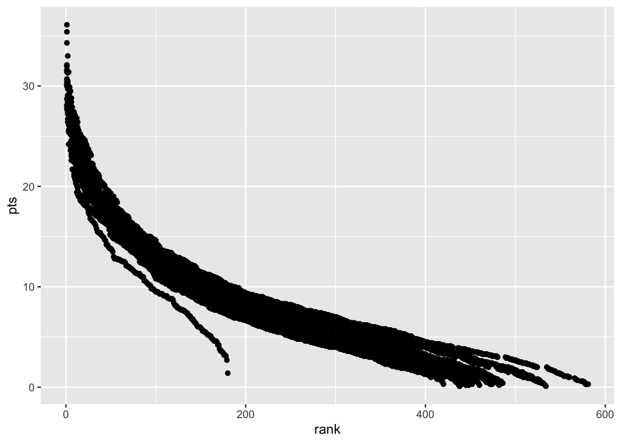

```r
# has a downward funnel shape
ggplot(nba, mapping = aes(x = rank, y = pts)) +
  geom_point()
```

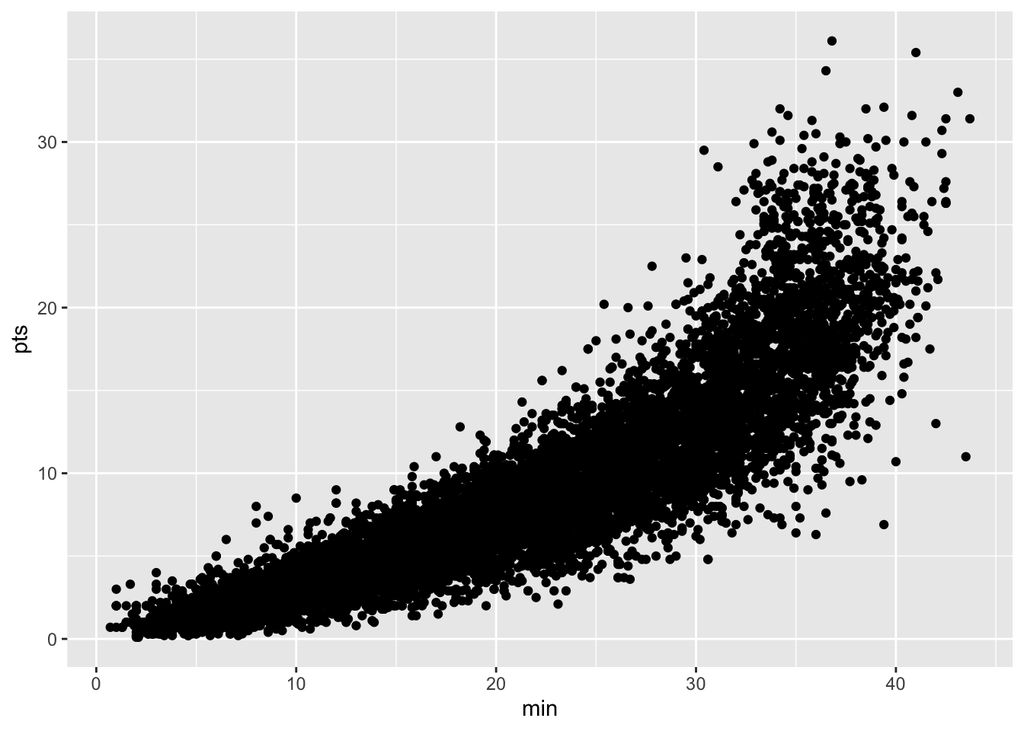

```r
# has a funnel shape
ggplot(nba, mapping = aes(x = min, y = pts)) +
  geom_point()
```

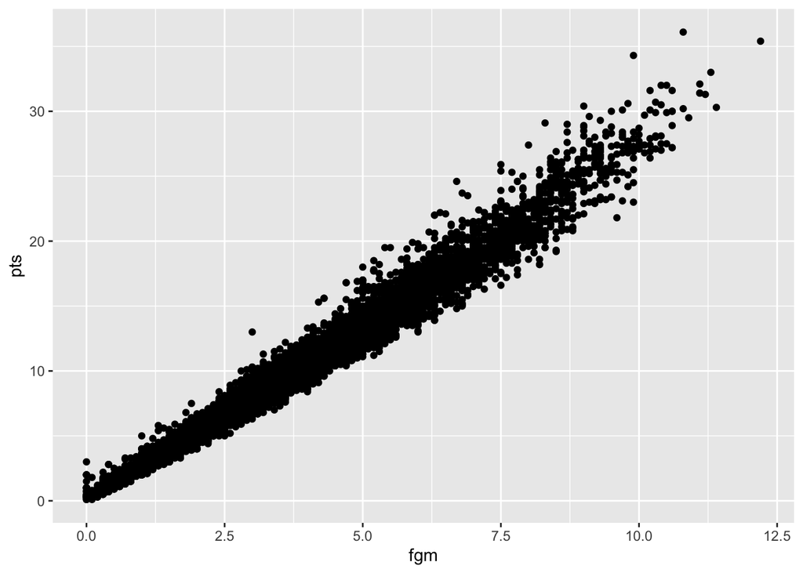

```r
# no obvious shapes for these variables
ggplot(nba, mapping = aes(x = fgm, y = pts)) +
  geom_point()
```

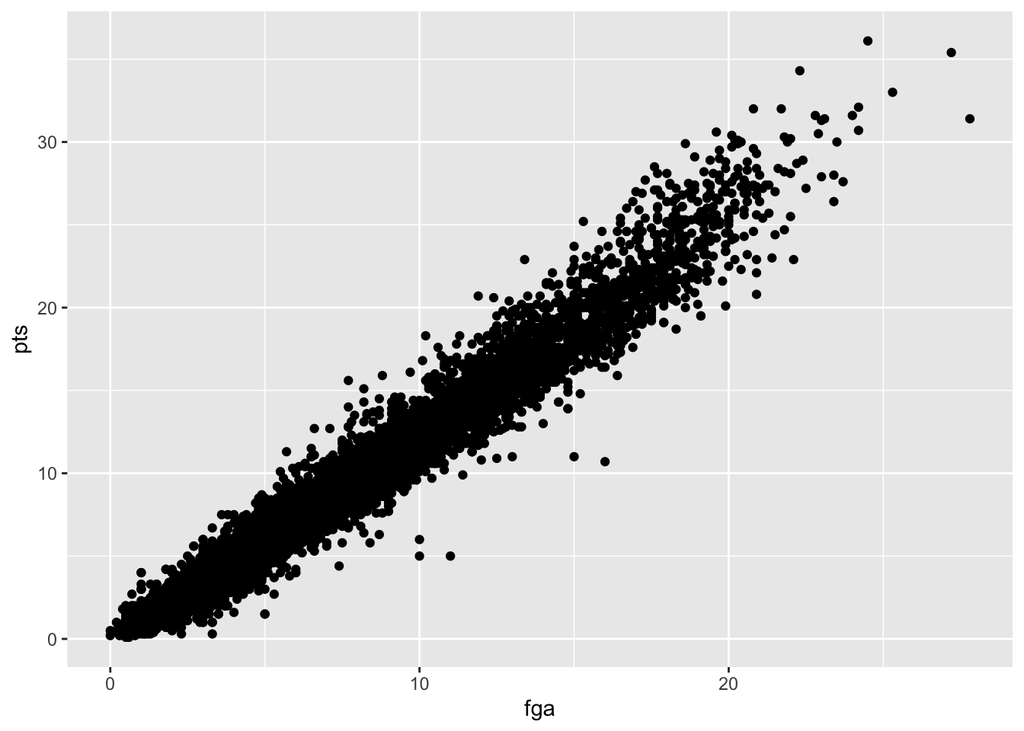

```r
ggplot(nba, mapping = aes(x = fga, y = pts)) +
  geom_point()
```

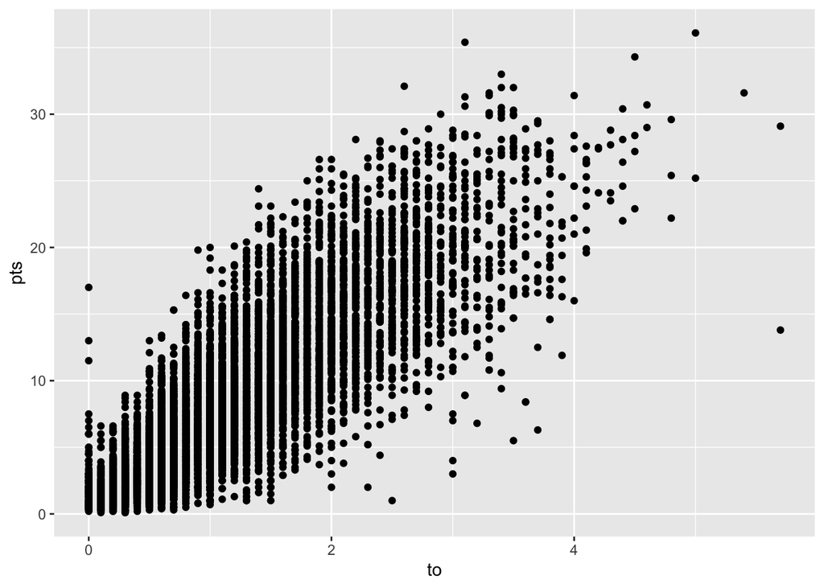

```r
ggplot(nba, mapping = aes(x = to, y = pts)) +
  geom_point()
```

Based on the plots above, there may need to be a log transformation to certain variables (`min`, `rank`)as there is a funnel shape with these variables and the outcome variable.

## Outline for Data Splitting

Since any issues found in the data are minor and have been mostly corrected above, the data will be used for the remainder of the project. The data will be split with 3 to 4 split, since the data set is large, more data can be allocated to the training set. The data will be split using `initial_split()` and will be stratified by the variable `pts`. I chose to do stratified sampling as there is wide range in metrics in the data, so I wanted to ensure that the data set population is represented accurately.